# BACE legacy effects analysis

Eric R. Scott

24 October, 2021

# 1 Longitudinal Growth

## 1.1 Methods

To determine the effects of the historical and current precipitation treatments on crop growth, we analyzed the effects of the treatments on change in height over time. Because kale grows indeterminately , we used height data from the entire experiment from Jul 2 to Oct 9 (Figure 1.1a). Oats and beans, on the other hand, switched from growth to reproduction and we only used data from the growing phase to analyze effects on height (Figure 1.1b,c). This was Jul 2 to Aug 7 for oats and Jul 2 to Jul 31 for beans. We used linear mixed effects models to model height as a function of date, historical treatment, current treatment, their three-way interaction, and all two-way interactions among them. Additionally, early herbivory incidence (mainly small mammal herbivory) and house ID were included as fixed effects. Pot ID and plant ID were included as random effects. For kale and beans, height was log transformed to meet model assumptions. Height data for oats was left untransformed as the untransformed data better fit model assumptions of linearity and homogeneity of variances. Models were fit using the `lme4` package (Bates et al., 2015). Because we were primarily interested in the fitted slope of height as a function of date, we focused our interpretation on two- and three-way interactions with date using the `emtrends()` function from the `emmeans` package (Lenth, 2021).

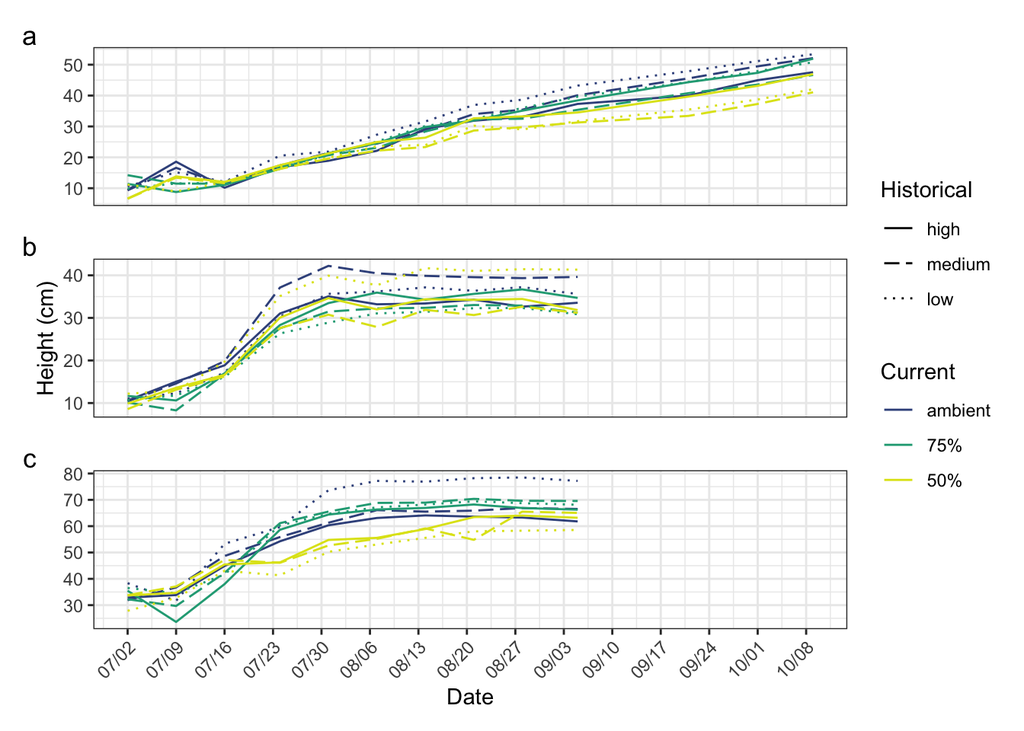

Figure 1.1: Weekly change in height of kale (a), beans (b), and oats (c).

## 1.2 Results

### 1.2.1 Kale

```
## Analysis of Deviance Table (Type II Wald chisquare tests)
##
## Response: log(height)
##                                Chisq Df Pr(>Chisq)
## days                       6183.4896  1  < 2.2e-16 ***
## hist_treat                    1.3314  2  0.5139235
## curr_treat                    2.9203  2  0.2321981
## july_herbivory                0.5473  1  0.4594128
## house                         0.1188  2  0.9423269
## days:hist_treat               5.4560  2  0.0653497 .
## days:curr_treat               5.5840  2  0.0612973 .
## hist_treat:curr_treat         1.4294  4  0.8390651
## days:hist_treat:curr_treat   22.7470  4  0.0001422 ***
## ---
## Signif. codes:  0 '***' 0.001 '**' 0.01 '*' 0.05 '.' 0.1 ' ' 1
```

The change in height over time is statistically significant (p < 0.001). There is a significant three-way interaction between day, historical treatment, and current treatment. This means that the slope of height over days depends on the interaction between historical and current treatment (I think; 3-way interactions are difficult to interpret) (Figure 1.2a).

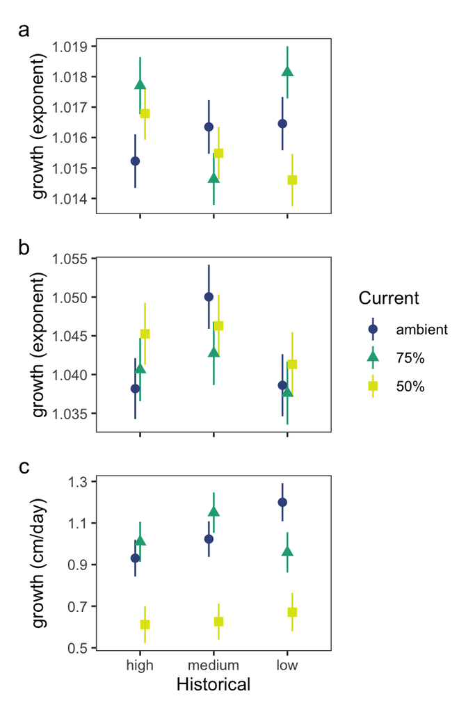

Figure 1.2: Fitted growth rates from (generalized) linear mixed effects models of crop height as a function of day, herbivory, historical and current treatments, their interaction, and the three-way interaction between day, historical, and current treatments. For kale (a) and beans (b), the y-axis is fitted values from a log-link gaussian GLMM modeling exponential growth. For oats (c), the y-axis is fitted values from an identity-link model and represent linear growth rates.

### 1.2.2 Beans

```
## Analysis of Deviance Table (Type II Wald chisquare tests)
##
## Response: log(height)
##                                Chisq Df Pr(>Chisq)
## days                       2020.9315  1  < 2.2e-16 ***
## hist_treat                    0.7930  2   0.672658
## curr_treat                    1.6269  2   0.443324
## july_herbivory                1.1190  1   0.290138
## house                         2.0630  2   0.356477
## days:hist_treat               9.6117  2   0.008182 **
## days:curr_treat               2.8228  2   0.243802
## hist_treat:curr_treat         6.4720  4   0.166563
## days:hist_treat:curr_treat    4.3877  4   0.356076
## ---
## Signif. codes:  0 '***' 0.001 '**' 0.01 '*' 0.05 '.' 0.1 ' ' 1
```

- days = significant growth (change in height over time)
- days:hist_treat = different slopes (height over time) for different historical treatments (Figure 1.2b).

### 1.2.3 Oats

```
## Analysis of Deviance Table (Type II Wald chisquare tests)
##
## Response: height
##                                Chisq Df Pr(>Chisq)
## days                       1744.8946  1  < 2.2e-16 ***
## hist_treat                    2.5853  2   0.274536
## curr_treat                   13.1511  2   0.001394 **
## july_herbivory                2.3729  1   0.123456
## house                        20.2049  2  4.098e-05 ***
## days:hist_treat               3.8194  2   0.148124
## days:curr_treat              81.2604  2  < 2.2e-16 ***
## hist_treat:curr_treat         6.8561  4   0.143693
## days:hist_treat:curr_treat    9.9094  4   0.041981 *
## ---
## Signif. codes:  0 '***' 0.001 '**' 0.01 '*' 0.05 '.' 0.1 ' ' 1
```

- days = significant growth (change in height over time)
- house = significant blocking effect (weeds?)
- curr_treat = different intercepts for different treatments
- days:curr_treat = different slopes (height over time) for different current treatments
- days:hist_treat:curr_treat = hard to interpret, especially since no main effects
- Figure 1.2c

# 2 Nutrient Analysis

## 2.1 Methods

To understand how current and historical precipitation treatments affected crop nutrients we used partial redundancy analysis (partial RDA), a supervised multivariate technique (Brocard, 2006). We modeled the effects of historical treatment, current treatment, their interaction, early herbivory (small mammal), and late herbivory (arthropods) on crop nutrients while controlling for the effect of house (i.e. house was used as a conditional variable and “partialed out”). Partial RDA was performed on centered and scaled nutrient data using the `rda` function from the `vegan` package (Oksanen et al., 2020). RDA significance was determined with permutation tests performed using the `RVAideMemoire` package (Hervé, 2021). Score plots and correlation plots were produced using packages `ggplot2` (Wickham, 2016), `ggrepel` (Slowikowski, 2021), and `ggpubr` (Kassambara, 2020). When the RDA was significant, we followed up with univariate ANOVAs for log-transformed concentrations of Fe, Zn, and N.

**NOTE**: From the help file for `rda()` in case it is helpful for revising the methods:

> Partial CCA (pCCA; or alternatively partial RDA) can be used to remove the effect of some conditioning or background or random variables or covariables before CCA proper. In fact, pCCA compares models cca(X ~ Z) and cca(X ~ Y + Z) and attributes their difference to the effect of Y cleansed of the effect of Z.

[in this case X is nutrients, Y is our predictors (current treatment, historical treatment, etc.) and Z is “house”]

**NOTE** `jul_herbivory` is cumulative herbivory in July, which was small-mammal herbivory. `late_herbivory` is the cumulative herbivory in August minus cumulative herbivory in July. Late herbivory was insect herbivory. So `jul_herbivory` is small mammal herbivory and `late_herbivory` is just the insect herbivory.

## 2.2 Results

### 2.2.1 Kale

Boxplot

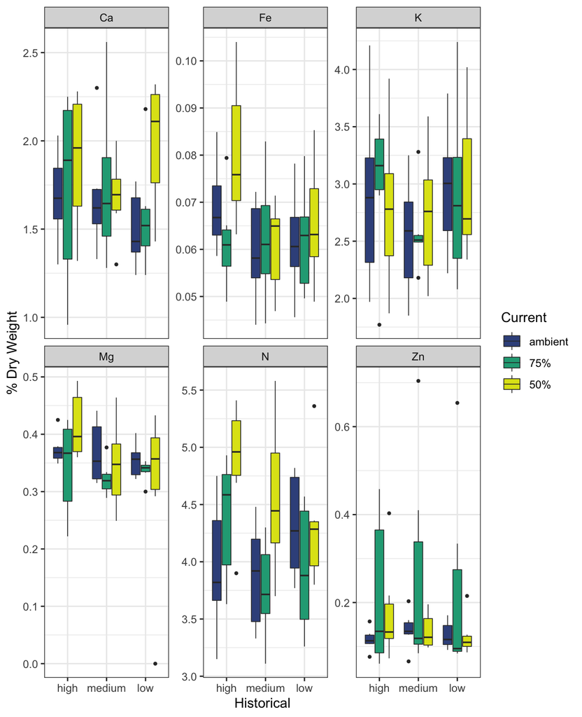

```
## Criterion: total variance (%)
##                Proportion Cumulative
##    Conditional      14.58      14.58
##    Constrained      28.66      43.24
##  Unconstrained      56.76     100.00
##
## Criterion: constrained variance (%)
##  Axis Proportion Cumulative
##     1      54.37      54.37
##     2      13.12      67.49
##     3      10.74      78.23
##     4       9.83      88.06
##     5       6.09      94.15
##
## Criterion: unconstrained variance (%)
##  Axis Proportion Cumulative
##     1      39.82      39.82
##     2      15.46      55.28
##     3      12.17      67.44
##     4       9.76      77.21
##     5       6.61      83.82
```

- 14.58% of variation in nutrients explained by “house”
- 28.66% of variation in nutrients explained by historical * current + jul_herbivory + late_herbivory
- Of the “constrained” variance, 67.49% is explained with the fist two axes.

```
## Permutation test for rda under reduced model
## Permutation: free
## Number of permutations: 999
##
## Model: rda(formula = nutr_df["nutr"] ~ historical * current + jul_herbivory + late_herbivory + Condition(house), data = nutr_df, scale = FALSE)
##          Df Variance      F Pr(>F)
## Model    10   3.1524 2.0702  0.001 ***
## Residual 41   6.2433
## ---
## Signif. codes:  0 '***' 0.001 '**' 0.01 '*' 0.05 '.' 0.1 ' ' 1
```

```
## Permutation test for rda under reduced model
## Type II tests
## Permutation: free
## Number of permutations: 999
##
## Model: rda(formula = nutr_df["nutr"] ~ historical * current + jul_herbivory + late_herbivory + Condition(house), data = nutr_df, scale = FALSE)
##                    Df Variance      F Pr(>F)
## historical          2   0.8609 2.8268  0.008 **
## current             2   1.0739 3.5261  0.002 **
## jul_herbivory       1   0.5647 3.7085  0.013 *
## late_herbivory      1   0.1687 1.1077  0.348
## historical:current  4   0.7900 1.2971  0.159
## Residual           41   6.2433
## ---
## Signif. codes:  0 '***' 0.001 '**' 0.01 '*' 0.05 '.' 0.1 ' ' 1
```

Historical treatment, current treatment, and early herbivory all significantly affected nutrients.

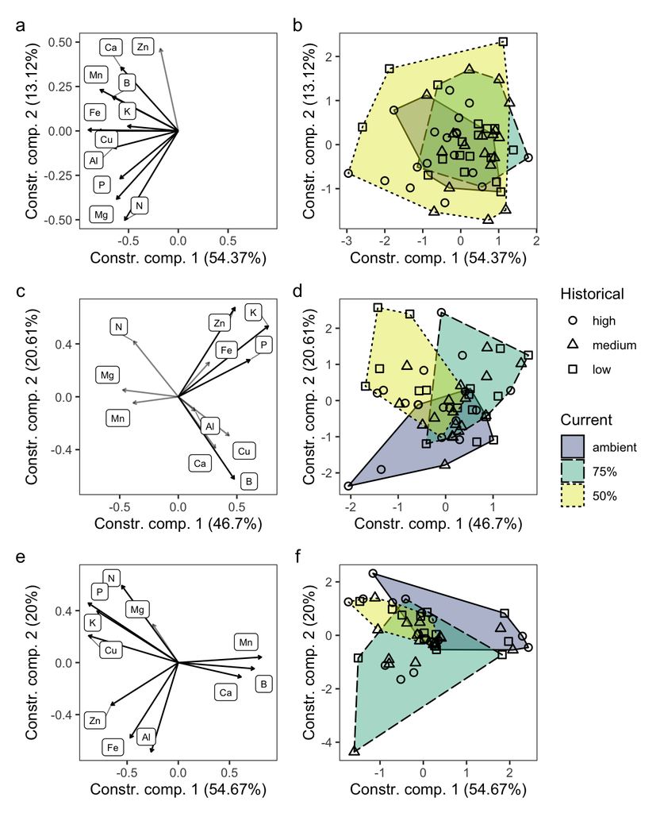

Figure 2.1: Redundancy analysis (RDA) correlation plots (a, c, e) and score plots (b,d,f) for kale (a,b), beans (c,d), and oats (e,f). In the correlation plots, greyed out arrows respresent nutrients that have a correlation < 0.5 to either axis

The first constrained component (the one that explains most of the variation due to predictors) explains about 54% of the variation explained by the predictors (less if you’d rather report the total variation in nutrients explained) (Figure 2.1a,b). This axis is negatively correlated with Fe, Cu, K, Al, etc (Figure 2.1a). Separation by historical and current treatment is minimal in the score plot (Figure 2.1b). Might be separation due to herbivory (not plotted)?

**Followup ANOVAs**

Fe:

```
## Anova Table (Type II tests)
##
## Response: log(fe)
##                     Sum Sq Df F value   Pr(>F)
## historical         0.21425  2  4.0970 0.023871 *
## current            0.24266  2  4.6404 0.015252 *
## jul_herbivory      0.16427  1  6.2825 0.016253 *
## late_herbivory     0.00003  1  0.0012 0.972216
## house              0.28317  2  5.4149 0.008188 **
## historical:current 0.13286  4  1.2703 0.297241
## Residuals          1.07202 41
## ---
## Signif. codes:  0 '***' 0.001 '**' 0.01 '*' 0.05 '.' 0.1 ' ' 1
```

N:

```
## Anova Table (Type II tests)
##
## Response: log(n)
##                     Sum Sq Df F value    Pr(>F)
## historical         0.06139  2  3.2464 0.0491131 *
## current            0.19457  2 10.2892 0.0002392 ***
## jul_herbivory      0.04231  1  4.4753 0.0405087 *
## late_herbivory     0.00376  1  0.3978 0.5317440
## house              0.19638  2 10.3854 0.0002244 ***
## historical:current 0.12662  4  3.3479 0.0184171 *
## Residuals          0.38765 41
## ---
## Signif. codes:  0 '***' 0.001 '**' 0.01 '*' 0.05 '.' 0.1 ' ' 1
```

Zn:

```
## Anova Table (Type II tests)
##
## Response: log(zn)
##                     Sum Sq Df F value  Pr(>F)
## historical          0.1364  2  0.2786 0.75826
## current             1.2994  2  2.6531 0.08250 .
## jul_herbivory       0.1254  1  0.5122 0.47825
## late_herbivory      0.3678  1  1.5018 0.22739
## house               2.1625  2  4.4153 0.01834 *
## historical:current  0.2262  4  0.2310 0.91941
## Residuals          10.0402 41
## ---
## Signif. codes:  0 '***' 0.001 '**' 0.01 '*' 0.05 '.' 0.1 ' ' 1
```

### 2.2.2 Beans

Boxplot

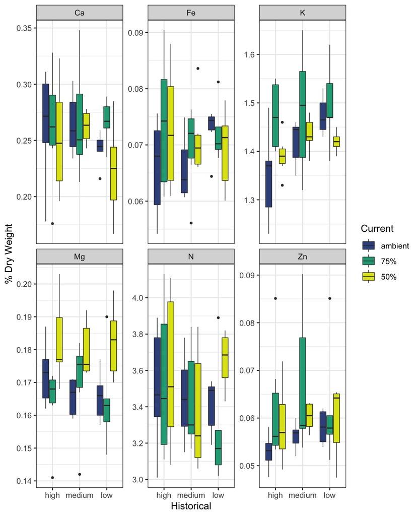

```
## Criterion: total variance (%)
##                Proportion Cumulative
##    Conditional      15.76      15.76
##    Constrained      23.83      39.59
##  Unconstrained      60.41     100.00
##
## Criterion: constrained variance (%)
##  Axis Proportion Cumulative
##     1      46.70      46.70
##     2      20.61      67.31
##     3      11.81      79.12
##     4       9.17      88.30
##     5       5.46      93.76
##
## Criterion: unconstrained variance (%)
##  Axis Proportion Cumulative
##     1      34.10      34.10
##     2      16.40      50.51
##     3      11.98      62.48
##     4      10.36      72.85
##     5       7.17      80.02
```

Omnibus test:

```
## Permutation test for rda under reduced model
## Permutation: free
## Number of permutations: 999
##
## Model: rda(formula = nutr_df["nutr"] ~ historical * current + jul_herbivory + late_herbivory + Condition(house), data = nutr_df, scale = FALSE)
##          Df Variance      F Pr(>F)
## Model    10   2.6212 1.5778  0.007 **
## Residual 40   6.6451
## ---
## Signif. codes:  0 '***' 0.001 '**' 0.01 '*' 0.05 '.' 0.1 ' ' 1
```

marginal effects test:

```
## Permutation test for rda under reduced model
## Type II tests
## Permutation: free
## Number of permutations: 999
##
## Model: rda(formula = nutr_df["nutr"] ~ historical * current + jul_herbivory + late_herbivory + Condition(house), data = nutr_df, scale = FALSE)
##                    Df Variance      F Pr(>F)
## historical          2   0.3282 0.9878  0.458
## current             2   1.1265 3.3906  0.001 ***
## jul_herbivory       1   0.0738 0.4441  0.886
## late_herbivory      1   0.2124 1.2785  0.245
## historical:current  4   0.8287 1.2471  0.192
## Residual           40   6.6451
## ---
## Signif. codes:  0 '***' 0.001 '**' 0.01 '*' 0.05 '.' 0.1 ' ' 1
```

- Only current treatment significant.
- Figure 2.1c,d

**Followup ANOVAs**

Fe:

```
## Anova Table (Type II tests)
##
## Response: log(fe)
##                     Sum Sq Df F value   Pr(>F)
## historical         0.01114  2  0.5124 0.602922
## current            0.03437  2  1.5816 0.218241
## jul_herbivory      0.03594  1  3.3074 0.076463 .
## late_herbivory     0.00358  1  0.3290 0.569468
## house              0.12061  2  5.5496 0.007463 **
## historical:current 0.06645  4  1.5286 0.212316
## Residuals          0.43468 40
## ---
## Signif. codes:  0 '***' 0.001 '**' 0.01 '*' 0.05 '.' 0.1 ' ' 1
```

N:

```
## Anova Table (Type II tests)
##
## Response: log(n)
##                      Sum Sq Df F value    Pr(>F)
## historical         0.007880  2  1.4334 0.2504842
## current            0.009535  2  1.7345 0.1894946
## jul_herbivory      0.006433  1  2.3404 0.1339275
## late_herbivory     0.000126  1  0.0458 0.8316252
## house              0.056469  2 10.2719 0.0002511 ***
## historical:current 0.018662  4  1.6973 0.1696539
## Residuals          0.109948 40
## ---
## Signif. codes:  0 '***' 0.001 '**' 0.01 '*' 0.05 '.' 0.1 ' ' 1
```

Zn:

```
## Anova Table (Type II tests)
##
## Response: log(zn)
##                     Sum Sq Df F value    Pr(>F)
## historical         0.02921  2  1.5851 0.2175211
## current            0.16351  2  8.8737 0.0006465 ***
## jul_herbivory      0.02322  1  2.5200 0.1202830
## late_herbivory     0.05172  1  5.6140 0.0227317 *
## house              0.08084  2  4.3872 0.0189390 *
## historical:current 0.03438  4  0.9329 0.4546652
## Residuals          0.36852 40
## ---
## Signif. codes:  0 '***' 0.001 '**' 0.01 '*' 0.05 '.' 0.1 ' ' 1
```

### 2.2.3 Oats

Boxplot

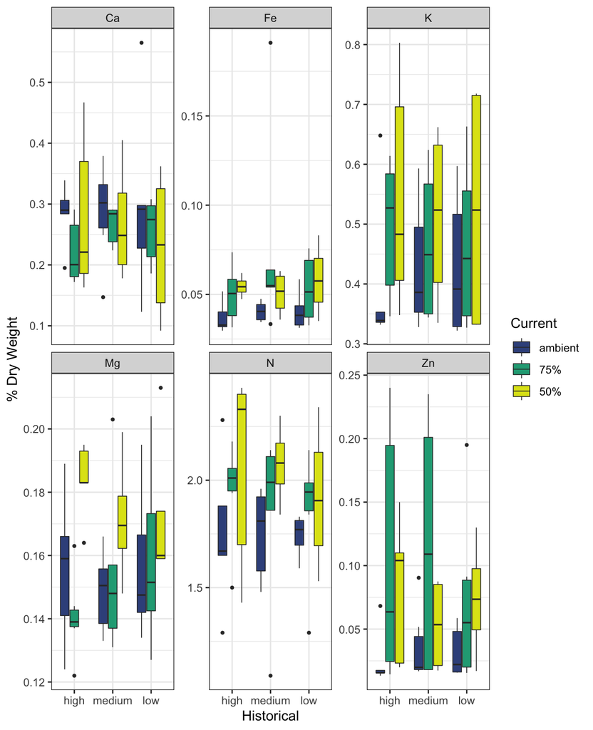

```
## Criterion: total variance (%)
##                Proportion Cumulative
##    Conditional      30.35      30.35
##    Constrained      21.90      52.25
##  Unconstrained      47.75     100.00
##
## Criterion: constrained variance (%)
##  Axis Proportion Cumulative
##     1      54.67      54.67
##     2      20.00      74.68
##     3      15.91      90.59
##     4       5.33      95.92
##     5       2.04      97.96
##
## Criterion: unconstrained variance (%)
##  Axis Proportion Cumulative
##     1      49.24      49.24
##     2      21.83      71.08
##     3      11.84      82.91
##     4       6.90      89.81
##     5       4.45      94.26
```

omnibus test:

```
## Permutation test for rda under reduced model
## Permutation: free
## Number of permutations: 999
##
## Model: rda(formula = nutr_df["nutr"] ~ historical * current + jul_herbivory + late_herbivory + Condition(house), data = nutr_df, scale = FALSE)
##          Df Variance     F Pr(>F)
## Model    10   2.4086 1.559  0.045 *
## Residual 34   5.2528
## ---
## Signif. codes:  0 '***' 0.001 '**' 0.01 '*' 0.05 '.' 0.1 ' ' 1
```

marginal effects test:

```
## Permutation test for rda under reduced model
## Type II tests
## Permutation: free
## Number of permutations: 999
##
## Model: rda(formula = nutr_df["nutr"] ~ historical * current + jul_herbivory + late_herbivory + Condition(house), data = nutr_df, scale = FALSE)
##                    Df Variance      F Pr(>F)
## historical          2   0.1623 0.5253  0.867
## current             2   1.5183 4.9137  0.001 ***
## jul_herbivory       1   0.1332 0.8621  0.472
## late_herbivory      1   0.3971 2.5702  0.072 .
## historical:current  4   0.3040 0.4919  0.967
## Residual           34   5.2528
## ---
## Signif. codes:  0 '***' 0.001 '**' 0.01 '*' 0.05 '.' 0.1 ' ' 1
```

- Only current treatment is significant
- Figure 2.1e,f

**Followup ANOVAs**

Fe:

```
## Anova Table (Type II tests)
##
## Response: log(fe)
##                     Sum Sq Df F value    Pr(>F)
## historical         0.14056  2  1.1485 0.3291230
## current            1.23086  2 10.0566 0.0003707 ***
## jul_herbivory      0.09386  1  1.5338 0.2240296
## late_herbivory     0.00114  1  0.0186 0.8924638
## house              0.69667  2  5.6921 0.0073751 **
## historical:current 0.23718  4  0.9689 0.4372083
## Residuals          2.08069 34
## ---
## Signif. codes:  0 '***' 0.001 '**' 0.01 '*' 0.05 '.' 0.1 ' ' 1
```

N:

```
## Anova Table (Type II tests)
##
## Response: log(n)
##                     Sum Sq Df F value  Pr(>F)
## historical         0.01232  2  0.2538 0.77733
## current            0.10353  2  2.1331 0.13406
## jul_herbivory      0.01278  1  0.5268 0.47293
## late_herbivory     0.06244  1  2.5730 0.11795
## house              0.16684  2  3.4374 0.04369 *
## historical:current 0.00928  4  0.0955 0.98320
## Residuals          0.82511 34
## ---
## Signif. codes:  0 '***' 0.001 '**' 0.01 '*' 0.05 '.' 0.1 ' ' 1
```

Zn:

```
## Anova Table (Type II tests)
##
## Response: log(zn)
##                     Sum Sq Df F value    Pr(>F)
## historical          0.3756  2  0.5212 0.5984659
## current             6.6148  2  9.1786 0.0006494 ***
## jul_herbivory       0.3909  1  1.0847 0.3049920
## late_herbivory      0.1011  1  0.2805 0.5997936
## house               5.7578  2  7.9895 0.0014314 **
## historical:current  0.7937  4  0.5507 0.6997880
## Residuals          12.2514 34
## ---
## Signif. codes:  0 '***' 0.001 '**' 0.01 '*' 0.05 '.' 0.1 ' ' 1
```

# 3 Biomass Analysis

## 3.1 Methods

To evaluate the effects of current and historical treatment on final biomass and root:shoot ratio, we used linear models (AKA ANOVAs) including historical treatment, current treatment, their interaction, early herbivory, late herbivory, and house as predictors.

If I remember correctly, this analysis only makes sense for kale.

## 3.2 Results

Total biomass:

```
## Anova Table (Type II tests)
##
## Response: mass_total
##                     Sum Sq Df F value Pr(>F)
## current              440.7  2  0.6019 0.5525
## historical           963.4  2  1.3157 0.2794
## jul_herbivory        159.1  1  0.4347 0.5134
## late_herbivory       965.7  1  2.6379 0.1120
## house               1116.1  2  1.5243 0.2299
## current:historical  2420.1  4  1.6526 0.1796
## Residuals          15010.6 41
```

No significant effect on biomass

Root:shoot ratio:

```
## Anova Table (Type II tests)
##
## Response: rs_ratio
##                      Sum Sq Df F value Pr(>F)
## current            0.005070  2  0.7157 0.4948
## historical         0.002871  2  0.4053 0.6694
## jul_herbivory      0.000042  1  0.0118 0.9140
## late_herbivory     0.001253  1  0.3537 0.5553
## house              0.000291  2  0.0410 0.9599
## current:historical 0.010206  4  0.7204 0.5830
## Residuals          0.145213 41
```

No significant effect on root:shoot ratio

# 4 References

Bates, D., Mächler, M., Bolker, B., Walker, S., 2015. Fitting linear mixed-effects models using lme4. Journal of Statistical Software 67, 1–48. https://doi.org/10.18637/jss.v067.i01

Brocard, D., 2006. Ordination in reduced space, in: Multivariate Analysis. Uneversité de Montréal, Montréal.

Hervé, M., 2021. RVAideMemoire: Testing and plotting procedures for biostatistics.

Kassambara, A., 2020. Ggpubr: ’ggplot2’ based publication ready plots.

Lenth, R.V., 2021. Emmeans: Estimated marginal means, aka least-squares means.

Oksanen, J., Blanchet, F.G., Friendly, M., Kindt, R., Legendre, P., McGlinn, D., Minchin, P.R., O’Hara, R.B., Simpson, G.L., Solymos, P., Stevens, M.H.H., Szoecs, E., Wagner, H., 2020. Vegan: Community ecology package.

Slowikowski, K., 2021. Ggrepel: Automatically position non-overlapping text labels with ’Ggplot2’.

Wickham, H., 2016. Ggplot2: Elegant graphics for data analysis. Springer-Verlag New York.

# 5 Reproducibility

**Reproducibility receipt**

```
## [1] "2021-10-24 10:59:13 EDT"
```

```
## Local:    master /Users/scottericr/Documents/BACE-legacy-effects
## Remote:   master @ origin (https://github.com/Aariq/BACE-legacy-effects.git)
## Head:     [151ba32] 2021-10-24: add boxplots to report
```